# SOMBrero GSOC Tests

Solution for easy, medium & hard tests

Shubham Garg

shubhamgrg04@gmail.com

# Tests

## USArrests

### Example of using SOMbrero to analyze the `USArrests` dataset

This example illustrates the usage of SOMBrero package for analysing `USArrests` dataset. This dataset contains statistics, in arrests per 100,000 residents for assault, murder, and rape in each of the 50 US states in 1973.

```r
data(USArrests)
head(USArrests)
```

```
##            Murder Assault UrbanPop Rape
## Alabama      13.2     236       58 21.2
## Alaska       10.0     263       48 44.5
## Arizona       8.1     294       80 31.0
## Arkansas      8.8     190       50 19.5
## California    9.0     276       91 40.6
## Colorado      7.9     204       78 38.7
```

#### Training the SOM

All four variables of the dataset are used to map each city on the SOM grid.

```r
library(SOMbrero)
set.seed(557)
my.som <- trainSOM(x.data=USArrests, dimension=c(5,8), nb.save=10, maxit=2000, scaling="none", radius.type="letremy", verbose="true")
```

```
## Self-Organizing Map algorithm...
##
##   Parameters of the SOM
##
##     SOM mode                       :  online
##     SOM type                       :  numeric
##     Affectation type               :  standard
##     Grid                           :
##       Self-Organizing Map structure
##
##         Features   :
##            topology     :  square
##            x dimension  :  5
##            y dimension  :  8
##            distance type:  letremy
##
##     Number of iterations           :  2000
##     Number of intermediate backups :  10
##     Initializing prototypes method :  random
##     Data pre-processing type       :  none
##     Neighbourhood type             :  letremy
##
## 0 % done
## 10 % done
## 20 % done
## 30 % done
## 40 % done
## 50 % done
## 60 % done
## 70 % done
## 80 % done
## 90 % done
## 100 % done
```

As the energy is saved 10 times using `nb.save=10` , we can have a look at its evolution. The energy evolves as shown in the following graphic:

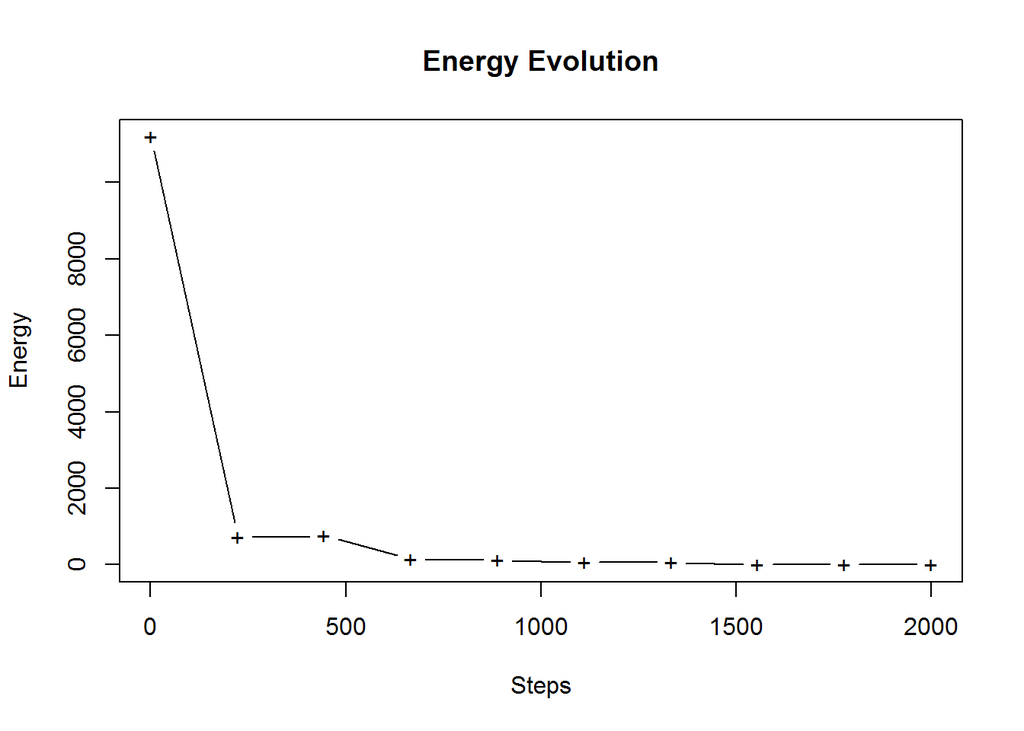

```r
plot(my.som, what="energy", main="Energy Evolution")
```

Energy stabilizes after 1500 steps.

#### Resulting Clustering

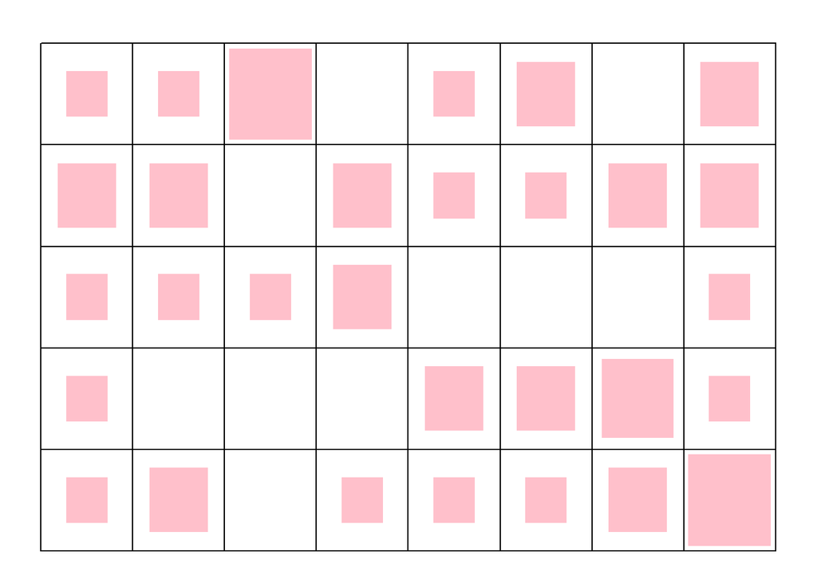

```r
plot(my.som, what="obs", type="hitmap")
```

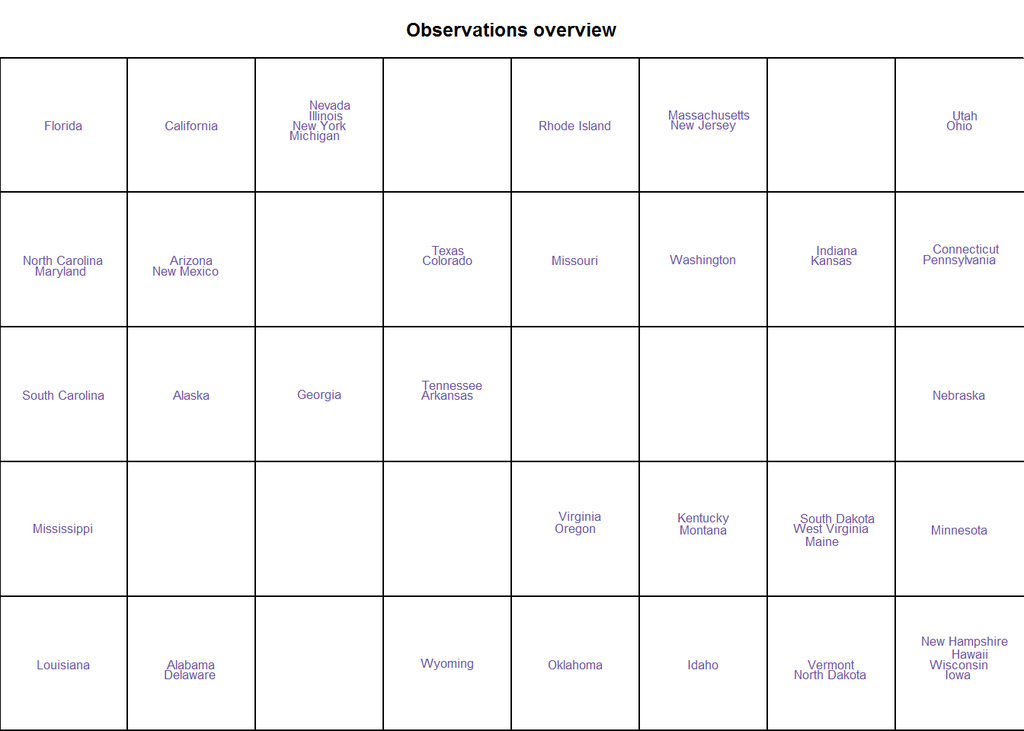

```r
plot(my.som, what="obs", type="names", scale=c(0.8, 0.9))
```

Above plot shows the cities which are assigned to vaious clusters.

To access the relevance of each explanatory variable in the definition of the clusters, the function summary includes an ANOVA with the factor being the clustering, for each (numeric) input variable.

```r
summary(my.som)
```

```
##
## Summary
##
##       Class :  somRes
##
##       Self-Organizing Map object...
##          online learning, type: numeric
##          5 x 8 grid with square topology
##          neighbourhood type: letremy
##          distance type: letremy
##
##       Final energy     : 2.546155
##       Topographic error: 0.04
##
##       ANOVA                :
##
##         Degrees of freedom :  29
##
##                F     pvalue significativity
## Murder     5.549 0.00009894             ***
## Assault  257.174 0.00000000             ***
## UrbanPop   5.385 0.00012408             ***
## Rape       3.903 0.00123192              **
```

Here, all variables have significantly different means among the different clusters (pvalue < 0.005) and can thus be considered to be relevant for the clustering definition.

#### Clustering Interpretation

`SOMBrero` provides a wide range of graphics to better understand the patterns behind resulting SOM.

##### **Plots showing variation of variables amongs clusters**

Now we will use plots provided by SOMBrero for visualizing variation of variables amongst different clusters.

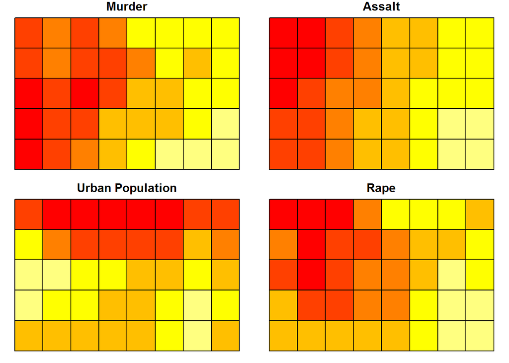

```r
par(mfrow=c(2,2))
plot(my.som, what="prototypes", type="color", var=1, main="Murder")
plot(my.som, what="prototypes", type="color", var=2, main="Assalt")
plot(my.som, what="prototypes", type="color", var=3, main="Urban Population")
plot(my.som, what="prototypes", type="color", var=4, main="Rape")
```

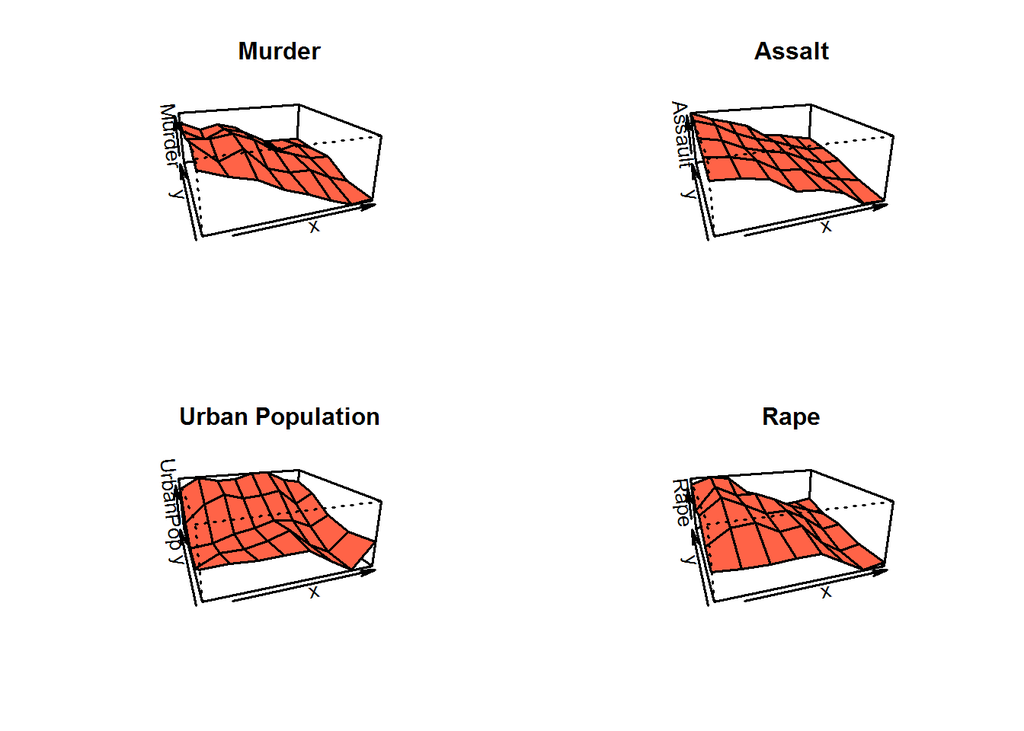

```r
par(mfrow=c(2,2))
plot(my.som, what="prototypes", type="3d", var=1, main="Murder")
plot(my.som, what="prototypes", type="3d", var=2, main="Assalt")
plot(my.som, what="prototypes", type="3d", var=3, main="Urban Population")
plot(my.som, what="prototypes", type="3d", var=4, main="Rape")
```

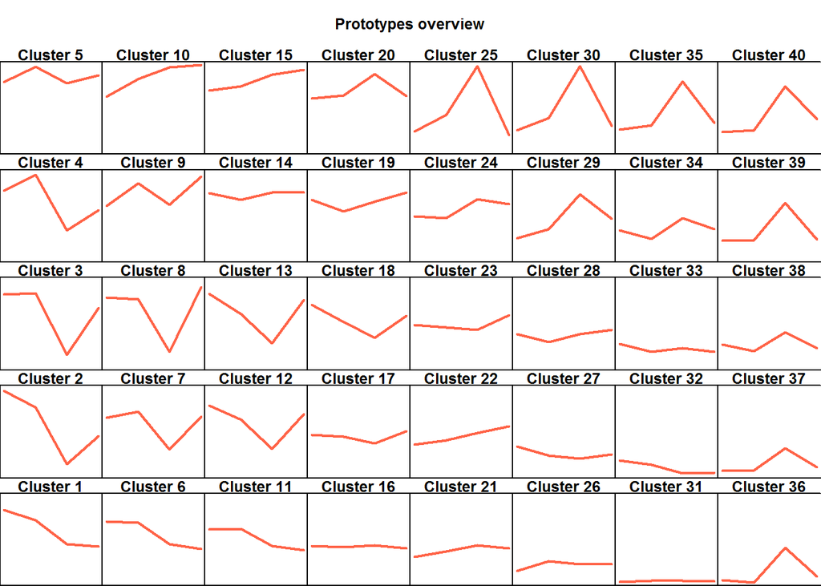

```r
plot(my.som, what="prototypes", type="lines", print.title=TRUE)
```

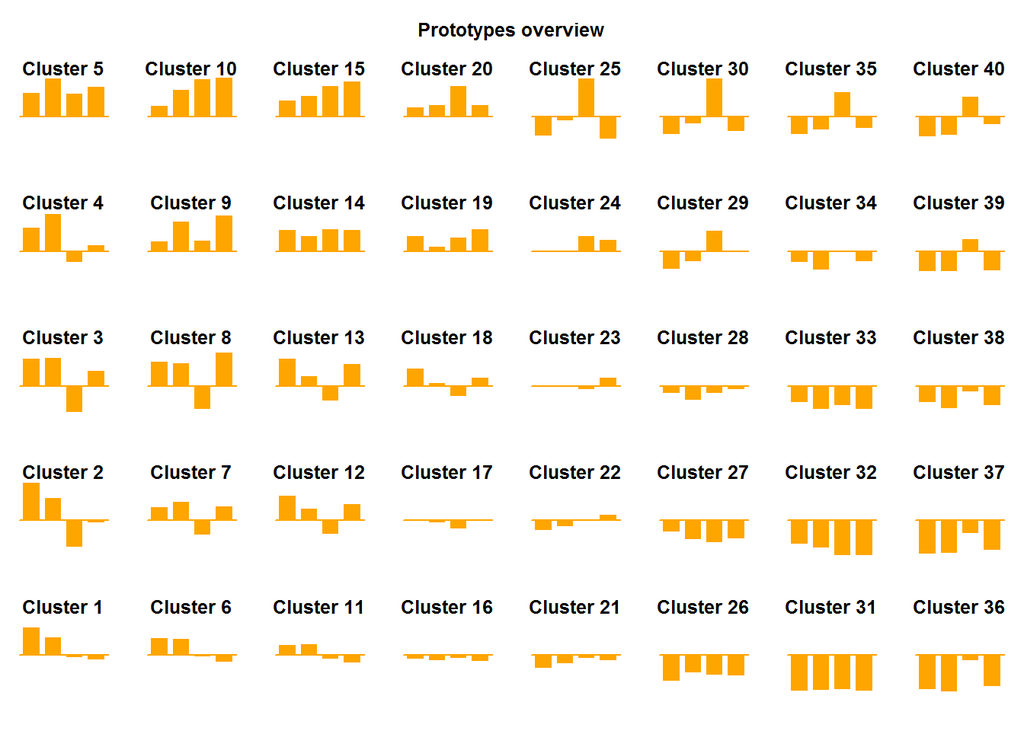

```r
plot(my.som, what="prototypes", type="barplot", print.title=TRUE)
```

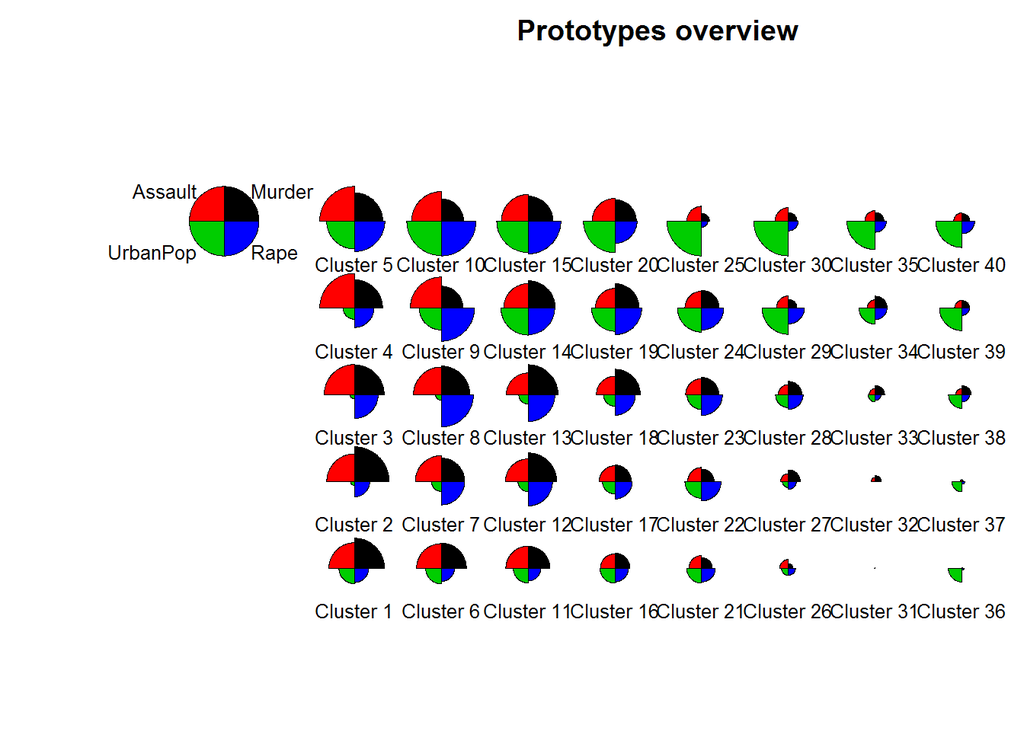

```r
plot(my.som, what="prototypes", type="radar", print.title=TRUE, , key.loc=c(-0.5,5), mar=c(0,10,2,0))
```

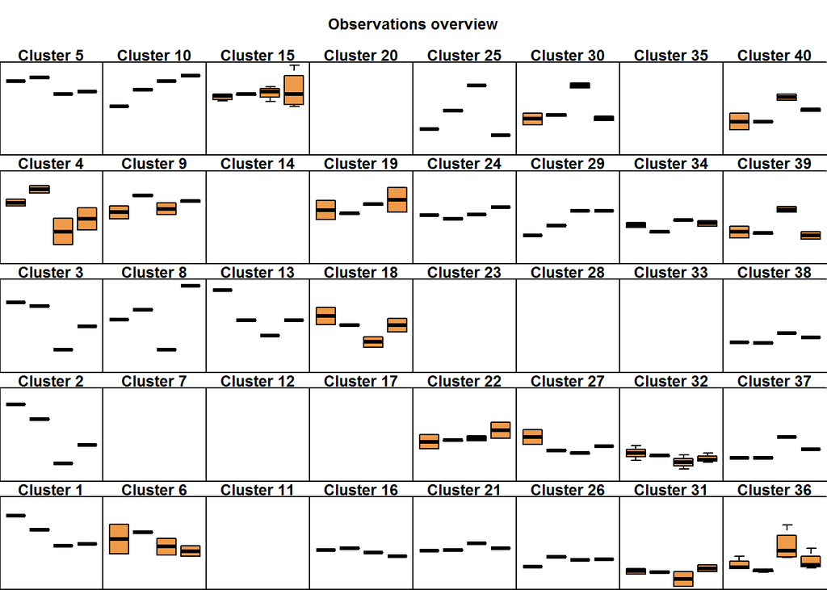

```r
plot(my.som, what="obs", type="boxplot", print.title=TRUE)
```

##### **Graphic to visualize distance between prototypes**

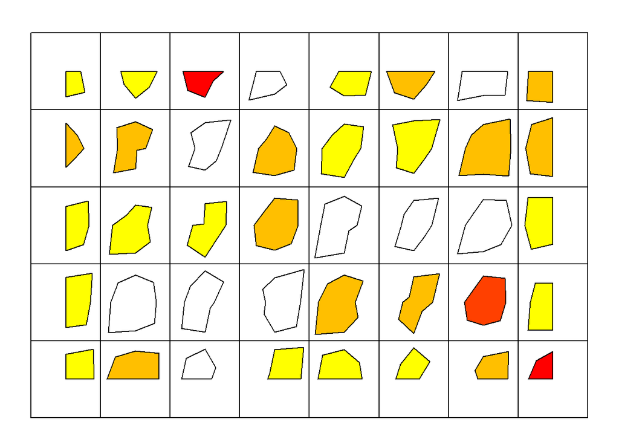

```r
plot(my.som, what="prototypes", type="poly.dist")
```

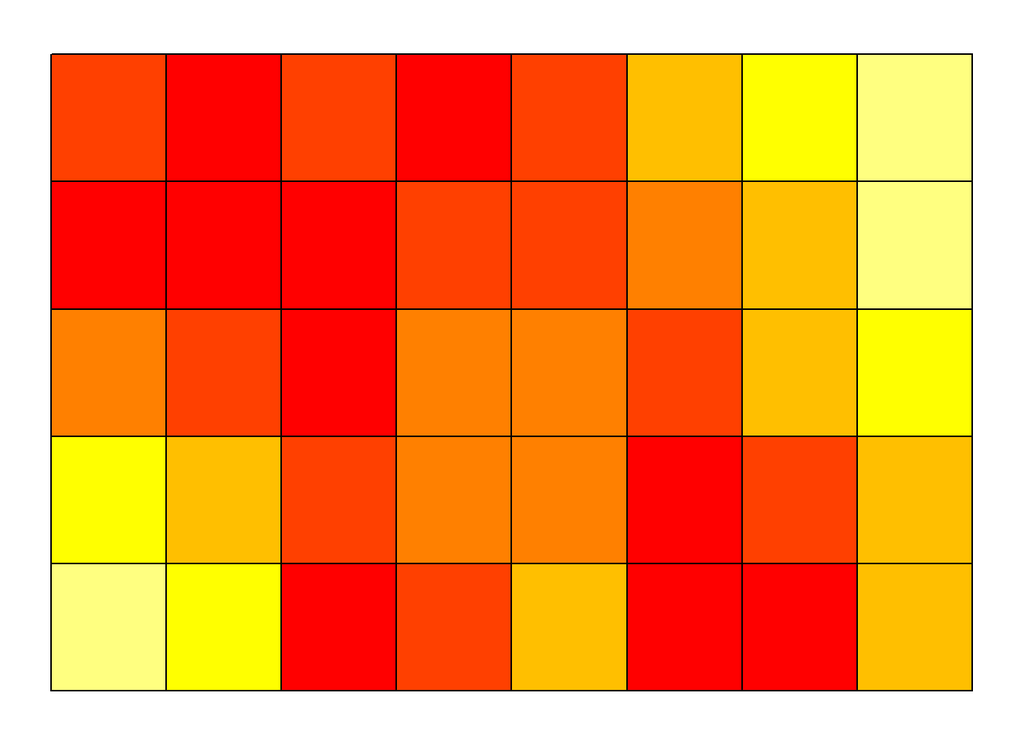

```r
plot(my.som, what="prototypes", type="umatrix")
```

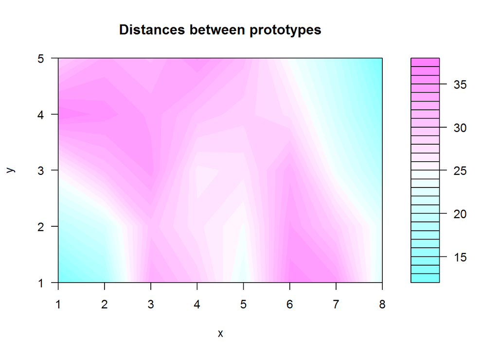

```r
plot(my.som, what="prototypes", type="smooth.dist")
```

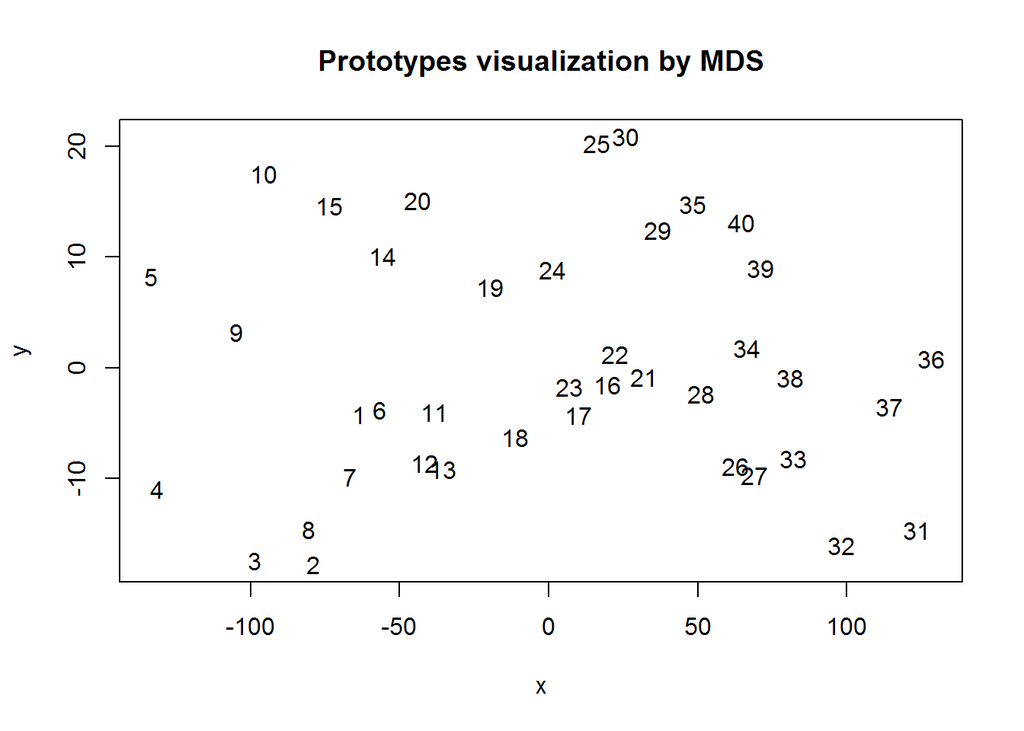

```r
plot(my.som, what="prototypes", type="mds")
```

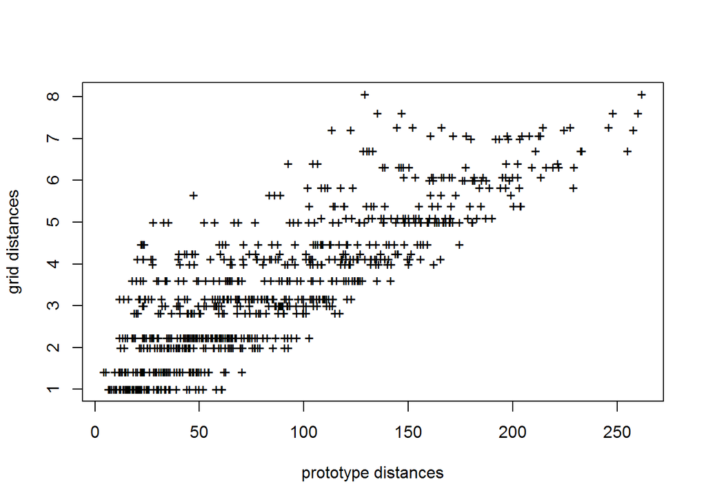

```r
plot(my.som, what="prototypes", type="grid.dist")
```

- “poly.dist” represents the distances between neighboring prototypes with polygons plotted for each cell of the grid. The smaller the distance between a polygon’s vertex and a cell border, the closer the pair of prototypes. The colors indicates the number of observations in the neuron (white is used for empty neurons);
- “umatrix” fills the neurons of the grid using colors that represent the average distance between the current prototype and its neighbors;
- “smooth.dist” plots the mean distance between the current prototype and its neighbors with a color gradation;
- mds plots the number of the neuron on a map according to a Multi Dimensional Scaling (MDS) projection;
- grid.dist plots a point for each pair of prototypes, with x coordinates representing the distance between the prototypes in the input space, and y coordinates representing the distance between the corresponding neurons on the grid.

These graphics show that there is a big gap (large distances) amongst the cities plotted in the top left corner of the map. Hence, for instance, the cities classified in cluster 3 are rather different from those classified in cluster 4, even if these two clusters are adjacent on the map. This is also emphasized on the MDS plot where clusters 3 and 4 are not very close.

#### **Predicting the cluster for an observation**

We can use `predict.somRes` function to predict the neuron, to which an observation is assigned .

```r
predict(my.som, USArrests[1,1:4])
```

```
## 6
## 6
```

#### **Analyze the projection quality**

```r
quality(my.som)
```

```
## $topographic
## [1] 0.04
##
## $quantization
## [1] 101.8462
```

By default, the quality function calculates both quantization and topographic errors. It is also possible to specify which one you want using the argument quality.type.

The quantization error is an unbounded positive number. The closer it is to 0, the better the projection quality.

#### **Building super classes from the resulting SOM**

In the SOM algorithm, the number of clusters is necessarily close to the number of neurons on the grid (not necessarily equal as some neurons may have no observations assigned to them). This - quite large - number may not suit the original data for a clustering purpose.

A usual way to address clustering with SOM is to perform a hierarchical clustering on the prototypes. This clustering is directly available in the package SOMbrero using the function `superClass`. To do so, you can first have a quick overview to decide on the number of super clusters which suits your data.

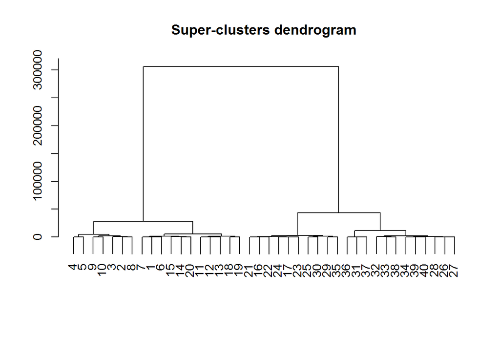

```r
plot(superClass(my.som))
```

```r
my.sc <- superClass(my.som, k=3)
summary(my.sc)
```

```
##
##    SOM Super Classes
##      Initial number of clusters :  40
##      Number of super clusters   :  3
##
##
##   Frequency table
##  1  2  3
## 18 10 12
##
##   Clustering
##  1  2  3  4  5  6  7  8  9 10 11 12 13 14 15 16 17 18 19 20 21 22 23 24 25
##  1  1  1  1  1  1  1  1  1  1  1  1  1  1  1  2  2  1  1  1  2  2  2  2  2
## 26 27 28 29 30 31 32 33 34 35 36 37 38 39 40
##  3  3  3  2  2  3  3  3  3  2  3  3  3  3  3
##
##
##   ANOVA
##
##         Degrees of freedom :  2
##
##                F     pvalue significativity
## Murder    47.194 0.00000000             ***
## Assault  131.518 0.00000000             ***
## UrbanPop   3.526 0.03742370               *
## Rape      19.283 0.00000077             ***
```

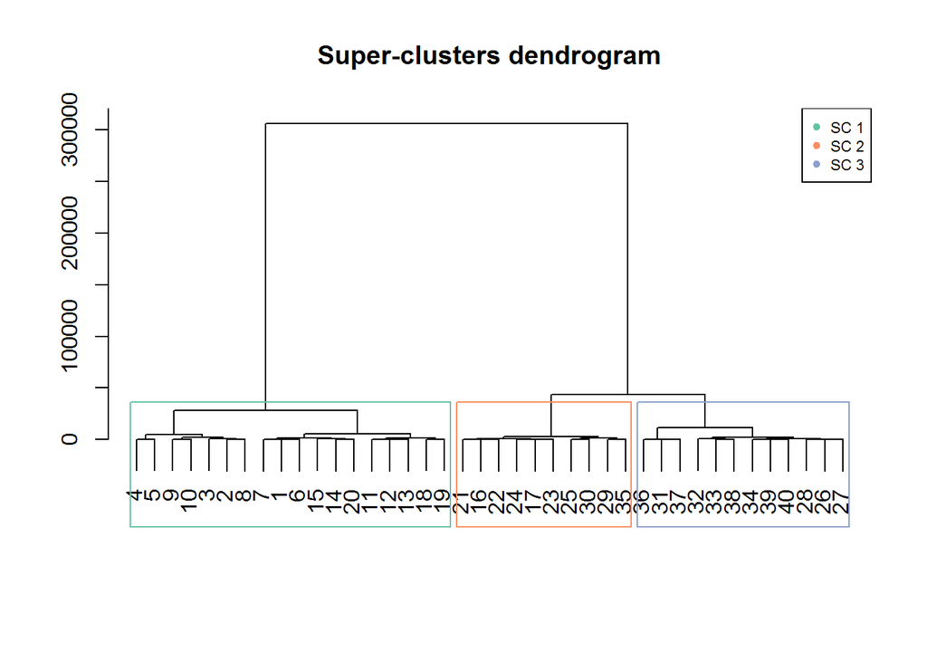

```r
plot(my.sc, plot.var=FALSE)
```

Like plot.somRes, the function `plot.somSC` has an argument type which offers many different plots and can thus be combined with most of the graphics produced by `plot.somSC`:

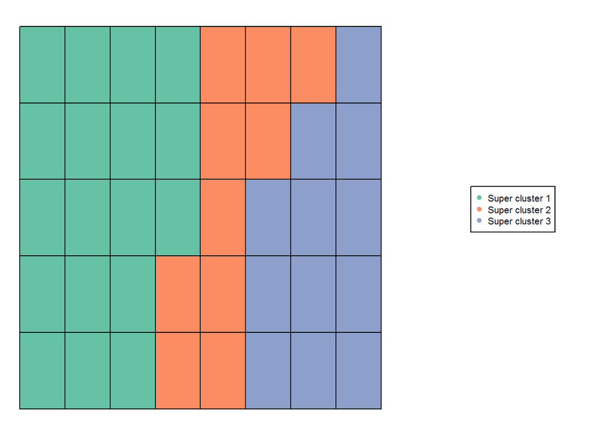

```r
plot(my.sc, type="grid", plot.legend=TRUE)
```

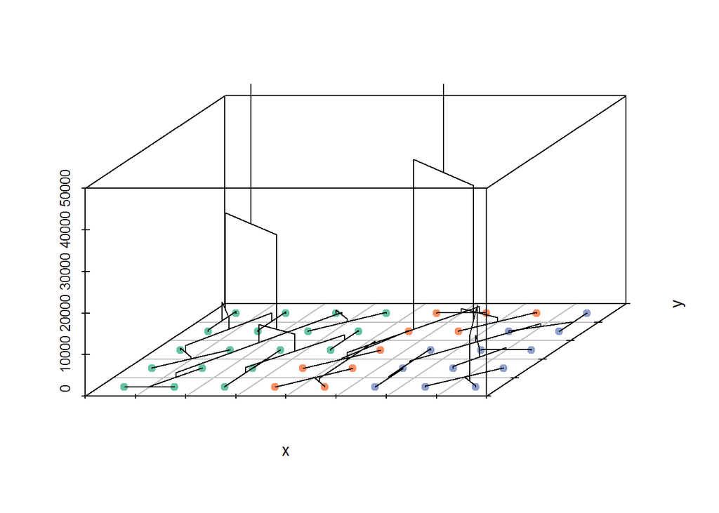

```r
plot(my.sc, type="dendro3d")
```

Case “grid” fills the grid with colors according to the super clustering (and can provide a legend). Case “dendro3d” plots a 3d dendrogram

Some of plots from `plot.somRes` are also available for the super clustering.

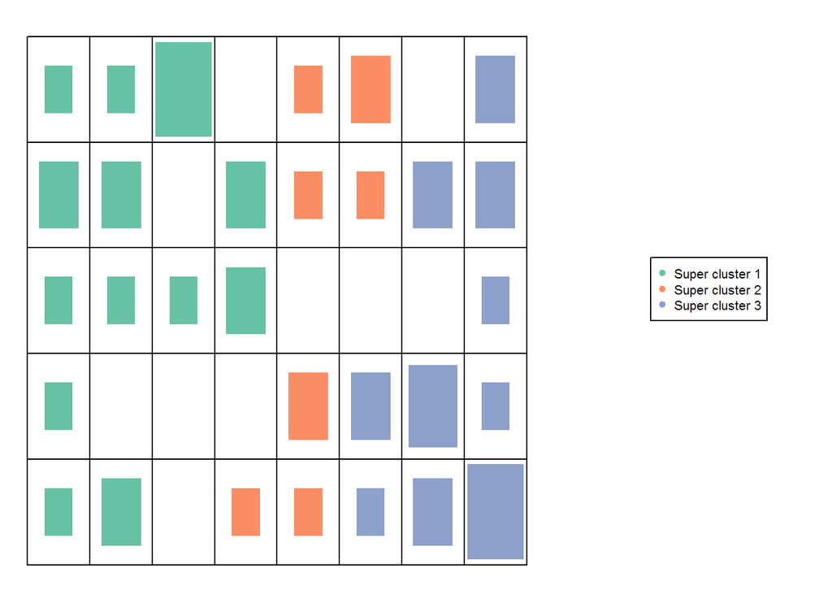

```r
plot(my.sc, type="hitmap", plot.legend=TRUE)
```

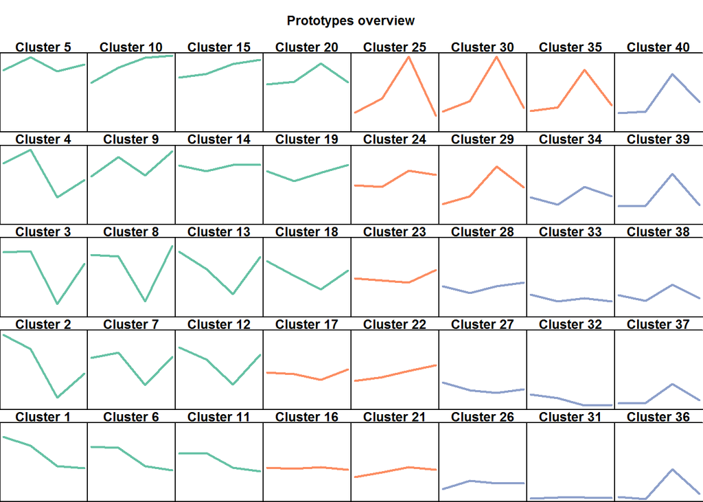

```r
plot(my.sc, type="lines", print.title=TRUE)
```

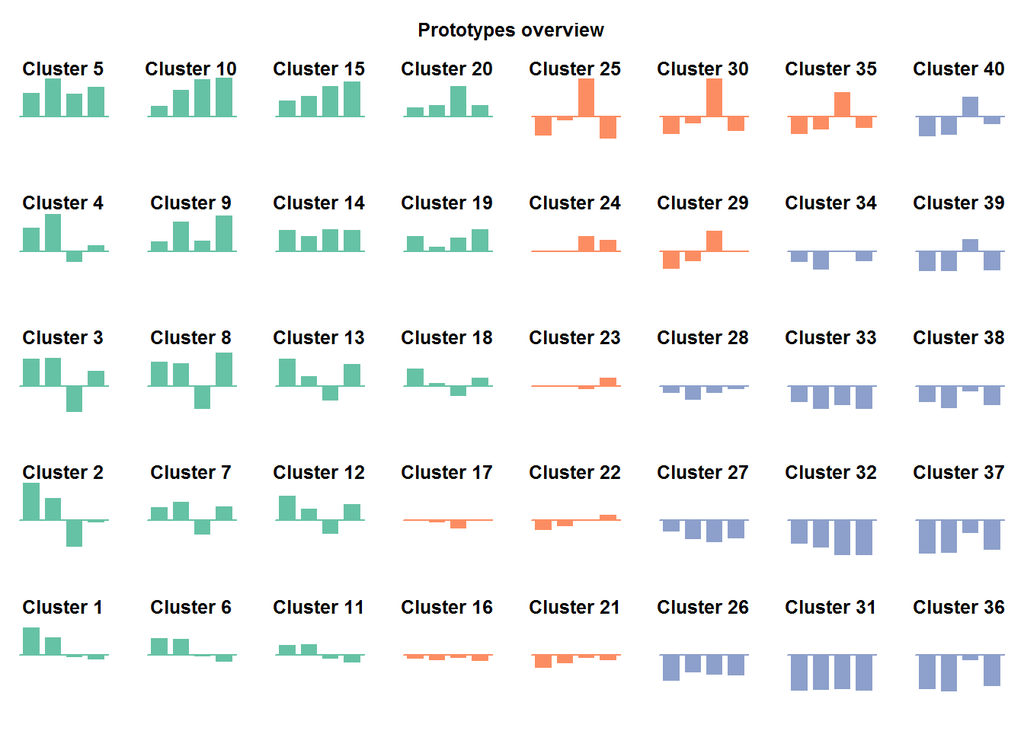

```r
plot(my.sc, type="barplot", print.title=TRUE)
```

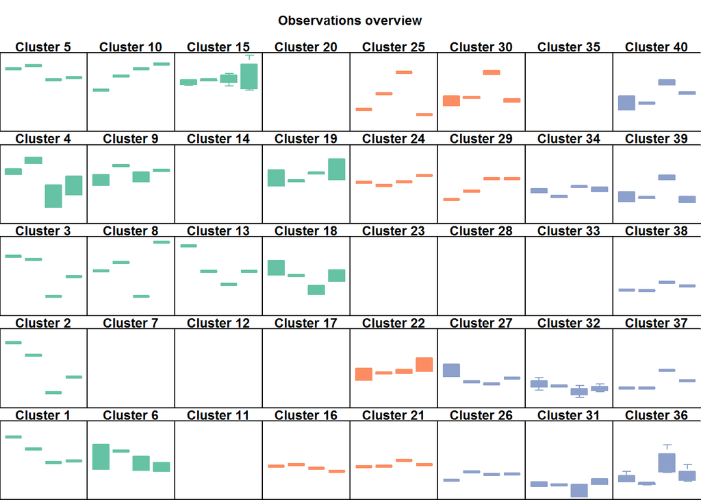

```r
plot(my.sc, type="boxplot", print.title=TRUE)
```

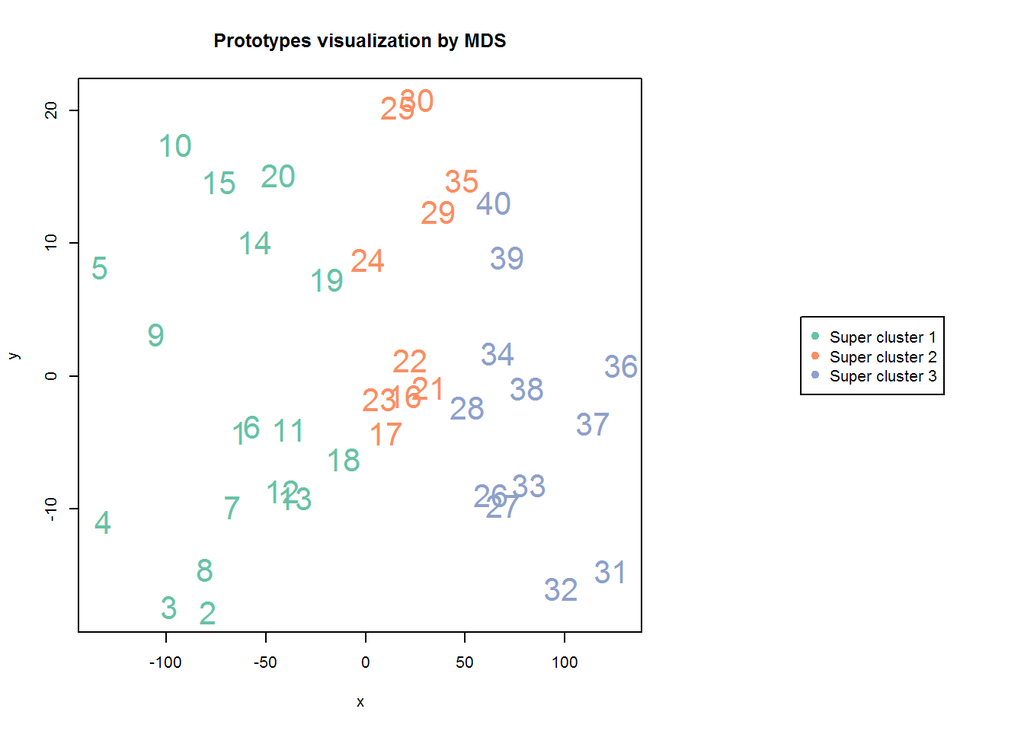

```r
plot(my.sc, type="mds", plot.legend=TRUE, cex =2)
```

And some others identify the super clusters with titles

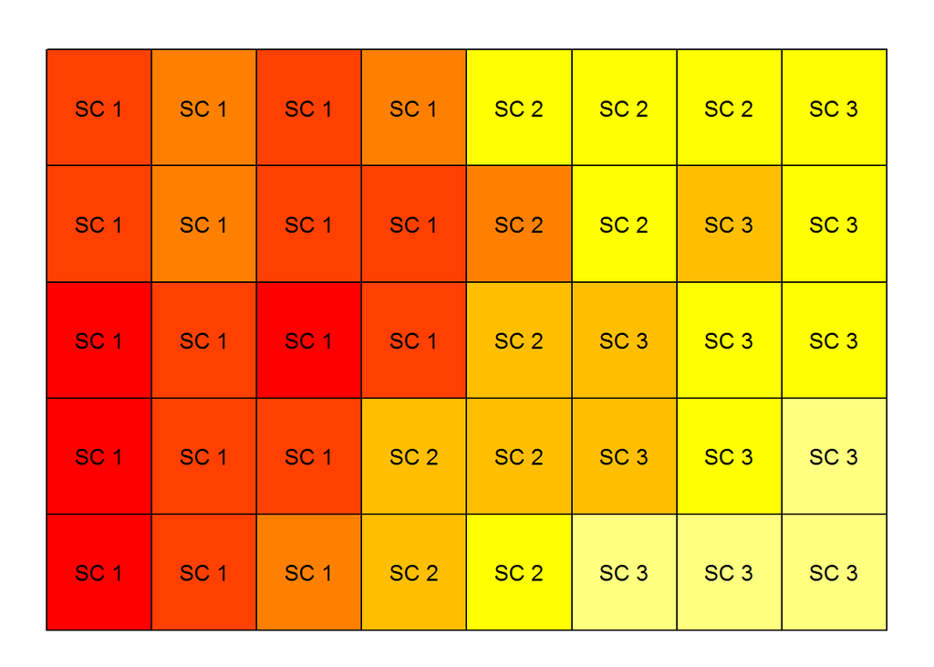

```r
plot(my.sc, type="color")
```

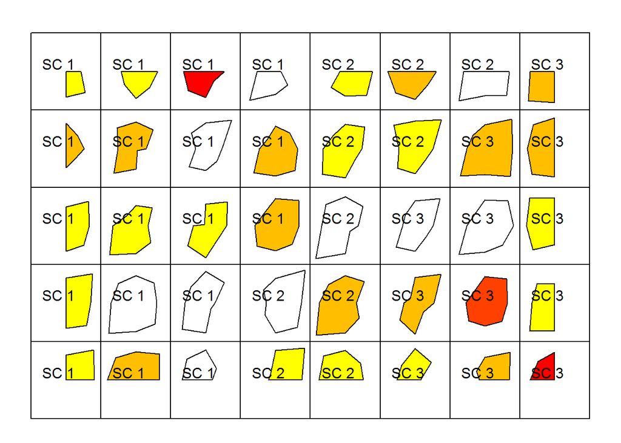

```r
plot(my.sc, type="poly.dist")
```

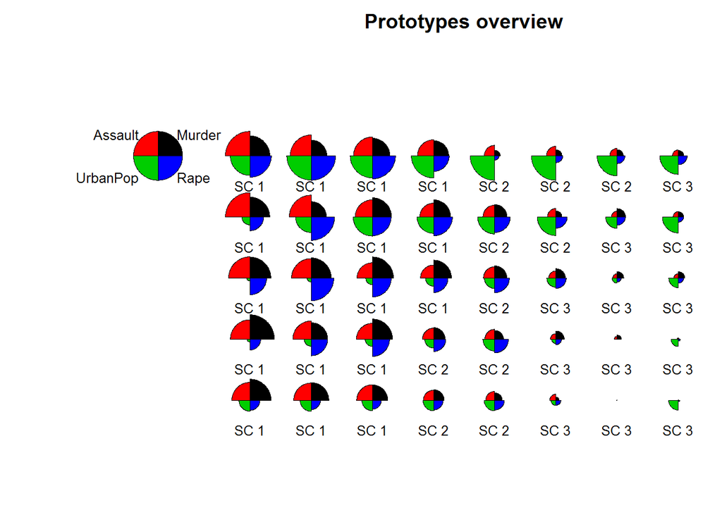

```r
plot(my.sc, type="radar", key.loc=c(-0.5,5), mar=c(0,10,2,0))
```

## Contingency Table

### Example of using SOMbrero to analyze the `HairEyeColor` dataset

The `HairEyeColor` provides distribution of hair and eye color and sex in 592 statistics students. In this example, we will be using data of Males in `HairEyeColor`.

```r
data <- HairEyeColor[,,1]
```

Appending “Eye” to eye colors and “Hair” to hair colors.

```r
colnames(data) <- c("EyeBrown", "EyeBlue", "EyeHazel", "EyeGreen")
rownames(data) <- c("HairBlack", "HairBrown", "HairRed", "HairBlond")
data
```

```
##            Eye
## Hair        EyeBrown EyeBlue EyeHazel EyeGreen
##   HairBlack       32      11       10        3
##   HairBrown       53      50       25       15
##   HairRed         10      10        7        7
##   HairBlond        3      30        5        8
```

```r
summary(data)
```

```
## Number of cases in table: 279
## Number of factors: 2
## Test for independence of all factors:
##  Chisq = 41.28, df = 9, p-value = 4.447e-06
##  Chi-squared approximation may be incorrect
```

#### **Training SOM**

```r
set.seed(557)
korresp.som <- trainSOM(x.data=data, dimension=c(3,3),
                        type="korresp", scaling="chi2", nb.save=10,
                        radius.type="letremy", maxit=600)
korresp.som
```

```
##       Self-Organizing Map object...
##          online learning, type: korresp
##          3 x 3 grid with square topology
##          neighbourhood type: letremy
##          distance type: letremy
```

As the energy is saved 10 times using `nb.save=10` , we can have a look at its evolution. The energy evolves as shown in the following graphic:

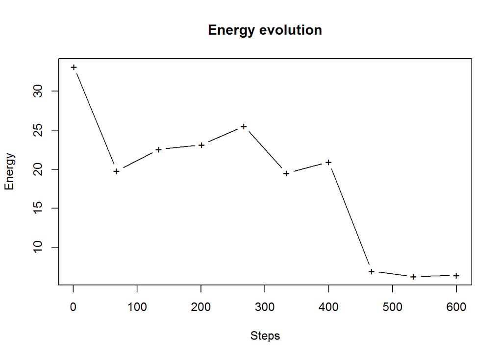

```r
plot(korresp.som, what="energy")
```

From the plot, we can see that the energy stabiizes after 500 iterations.

#### **Resulting clustering**

The clustering component contains the final classification of the dataset. As both row and column variables are classified, the length of the resulting vector is equal to the sum of the number of rows and the number of columns.

```r
korresp.som$clustering
```

```
##  EyeBrown   EyeBlue  EyeHazel  EyeGreen HairBlack HairBrown   HairRed
##         9         7         2         4         1         6         4
## HairBlond
##         7
```

The resulting distribution can be visualized using the following plots:

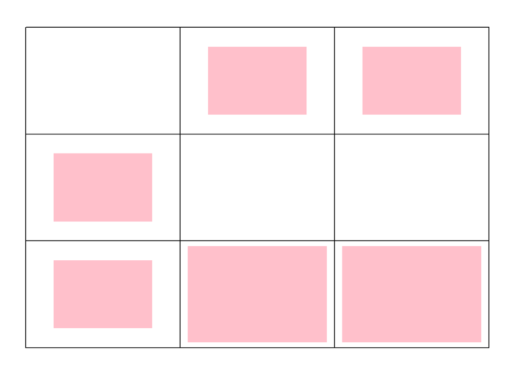

```r
plot(korresp.som, what="obs", type="hitmap")
```

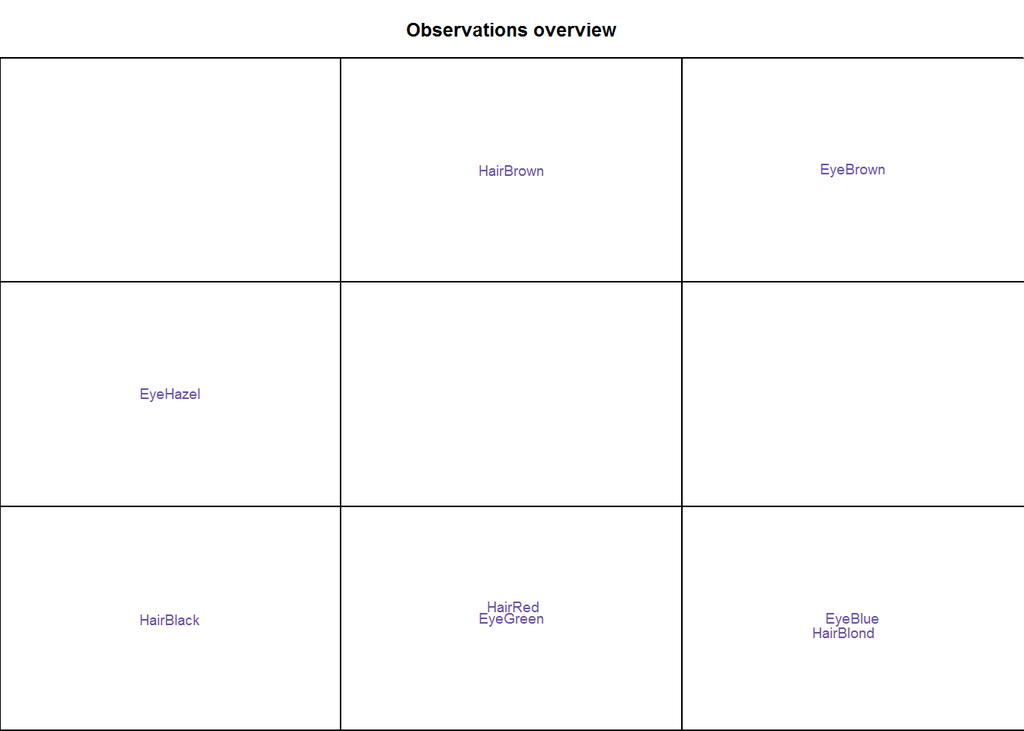

```r
plot(korresp.som, what="obs", type="names", scale=c(0.9,0.9))
```

The above graphics show that Males having Red hair generally are associated with males having Green eyes. Similarly, males with Blond hair are more associated with males having Blue eyes.